# Vota Unicamp!

Yasmine

# 1 Introdução

Em meio à crise em que o Brasil se encontra, a educação foi afetada com cortes de orçamento e, infelizmente, isso inclui Universidades. Diante disso, o movimento grevista tem tomado conta da Unicamp. A greve foi decidida por meio de assembleias estudantis, contudo muito se questiona a respeito da representatividade das decisões tomadas uma vez que existe pouca adesão. Com intuito de verificar qual a opinião da classe estudantil foi criado o site “https://votaunicamp.herokuapp.com/” para que os alunos matriculados tanto em cursos de graduação e pós graduação votassem e se quisessem justificassem o voto.

# 2 Objetivos

Deseja-se verificar a proporção de alunos contrários à greve estudantil. Além disso também temos o intuito de estudar o comportamento da classe, como por exemplo, se existe uma relação entre a área de estudo e o voto. Assim podemos caracterizar o perfil do aluno favorável ou contrário a mobilização.

# 3 Metodologia

## 3.1 Formatação de Dados

Extraímos do site uma tabela com o número de votos de cada curso, sim não e abstenho, incluindo cursos da Unicamp campus Limeira e Piracicaba.

```
##                                  Curso Total        Sim Abstenções
## 1                       1 - Matemática     3  2 (66.7%)   0 (0.0%)
## 2           1 - Mestrado em Matemática     1   0 (0.0%)   0 (0.0%)
## 3             10 - Engenharia Mecânica    40 10 (25.0%)   0 (0.0%)
## 4 10 - Mestrado em Engenharia Mecânica     4  2 (50.0%)   0 (0.0%)
## 5            100 - Ciências do Esporte     2   0 (0.0%)   0 (0.0%)
## 6       101 - Engenharia de Manufatura     3   0 (0.0%)   0 (0.0%)
##          Não
## 1  1 (33.3%)
## 2 1 (100.0%)
## 3 30 (75.0%)
## 4  2 (50.0%)
## 5 2 (100.0%)
## 6 3 (100.0%)
```

## 3.3 Análises Exploratórias

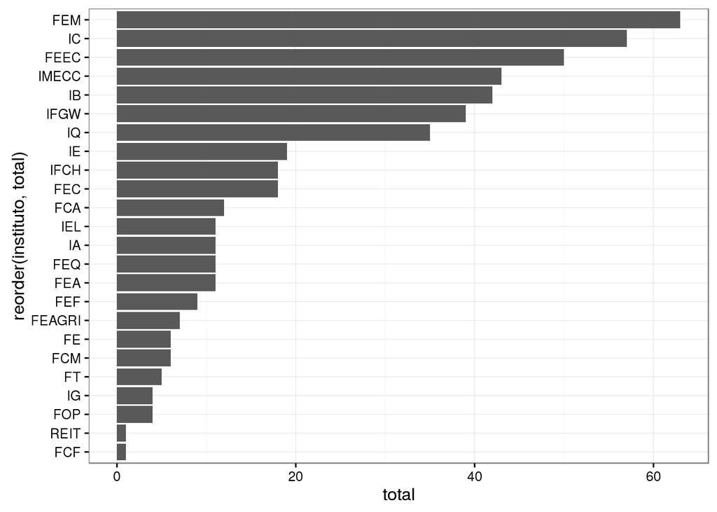

Gráfico do total de votos por instituto

| Instituto | Não | Sim | Abstenções | Total |
| --- | --- | --- | --- | --- |
| FCA | 12 | 0 | 0 | 12 |
| IFGW | 17 | 15 | 7 | 39 |
| FEM | 43 | 20 | 0 | 63 |
| IB | 25 | 15 | 2 | 42 |
| FEEC | 41 | 8 | 1 | 50 |
| FEC | 11 | 7 | 0 | 18 |
| FEA | 10 | 1 | 0 | 11 |
| FOP | 3 | 1 | 0 | 4 |
| FCM | 6 | 0 | 0 | 6 |
| IFCH | 5 | 13 | 0 | 18 |
| IE | 11 | 8 | 0 | 19 |
| IEL | 2 | 9 | 0 | 11 |
| IMECC | 33 | 9 | 1 | 43 |
| REIT | 1 | 0 | 0 | 1 |
| IA | 1 | 8 | 2 | 11 |
| FEF | 8 | 1 | 0 | 9 |
| IC | 43 | 11 | 3 | 57 |
| FT | 4 | 1 | 0 | 5 |
| FE | 5 | 1 | 0 | 6 |
| FEQ | 7 | 4 | 0 | 11 |
| IQ | 22 | 12 | 1 | 35 |
| IG | 1 | 3 | 0 | 4 |
| FCF | 1 | 0 | 0 | 1 |
| FEAGRI | 6 | 1 | 0 | 7 |